# FIFA Ratings - Explored and Explained

**Keith J. Mitchell**

Visit my project page: [Keith J. Mitchell's Project](https://KeithMitchell9.github.io)

## Project Description

The purpose of this project is to analyze a dataset related to player performance in the FIFA 22 videogame, specifically relating to an understanding of how overall ratings are calculated and whether or not they truly matter. To do this, I will be analyzing factors that may be influencing player ratings as well as examining any potential rating variations across positions. The final objective will focus aim on leveraging data analysis techniques to uncover insights about player ratings. Specifically, the goal is to analyze the dataset to investigate potential biases in how ratings are assigned to players. Potential bias could be based on their positions, attributes, nationalities, various other influences in the dataset. This analysis will help determine whether certain player characteristics disproportionately influence their ratings, allowing for a deeper understanding of the rating system and its fairness across different player types.

**Goals:**

- Understand relationships between player attributes and the overall player rating (`overall`).
- Identify key predictors for building a regression model to predict `overall` ratings.
- Prepare the dataset for modeling by understanding trends, correlations, and potential feature transformations.

**Target Variable**: `overall` player rating

**Predictor Variables**: Player attributes such as `pace`, `shooting`, `passing`, `defending`, and more

## The Dataset

### FIFA 22 Complete Player Dataset

- **Description:** This dataset includes detailed information about players in FIFA 22, encompassing player data such as rating, position, skill moves, work rates, and physical stats. The dataset allows for analysis of player performance, comparisons across positions, and identification of trends in player statistics. The dataset encompasses thousands of players, making it a nice resource for analyzing trends in player performance and characteristics. Key metrics have the potential to reveal significant variations across different player demographics, which adds depth to the analysis process.
- **Question:** What factors most significantly influence a player's rating, and how do these factors vary across different positions in the game? How do ratings change depending on position, and could there be some bias or skew in this dataset?

## Import Libraries

```python
import pandas as pd
import numpy as np
import re
import matplotlib.pyplot as plt
import seaborn as sns
from sklearn.model_selection import train_test_split
from sklearn.linear_model import LinearRegression
from sklearn.metrics import mean_absolute_error, mean_squared_error, r2_score
```

## Load the Dataset

```python
# Load the csv
fifa22_df = pd.read_csv('datasets/players_22.csv')

# Display the first few rows with all columns
fifa22_df
```

|  | sofifa_id | player_url | short_name | long_name | player_positions | overall | potential | value_eur | wage_eur | age | ... | lcb | cb | rcb | rb | gk | player_face_url | club_logo_url | club_flag_url | nation_logo_url | nation_flag_url |
| --- | --- | --- | --- | --- | --- | --- | --- | --- | --- | --- | --- | --- | --- | --- | --- | --- | --- | --- | --- | --- | --- |
| 0 | 158023 | https://sofifa.com/player/158023/lionel-messi/... | L. Messi | Lionel Andrés Messi Cuccittini | RW, ST, CF | 93 | 93 | 78000000.0 | 320000.0 | 34 | ... | 50+3 | 50+3 | 50+3 | 61+3 | 19+3 | https://cdn.sofifa.net/players/158/023/22_120.png | https://cdn.sofifa.net/teams/73/60.png | https://cdn.sofifa.net/flags/fr.png | https://cdn.sofifa.net/teams/1369/60.png | https://cdn.sofifa.net/flags/ar.png |
| 1 | 188545 | https://sofifa.com/player/188545/robert-lewand... | R. Lewandowski | Robert Lewandowski | ST | 92 | 92 | 119500000.0 | 270000.0 | 32 | ... | 60+3 | 60+3 | 60+3 | 61+3 | 19+3 | https://cdn.sofifa.net/players/188/545/22_120.png | https://cdn.sofifa.net/teams/21/60.png | https://cdn.sofifa.net/flags/de.png | https://cdn.sofifa.net/teams/1353/60.png | https://cdn.sofifa.net/flags/pl.png |
| 2 | 20801 | https://sofifa.com/player/20801/c-ronaldo-dos-... | Cristiano Ronaldo | Cristiano Ronaldo dos Santos Aveiro | ST, LW | 91 | 91 | 45000000.0 | 270000.0 | 36 | ... | 53+3 | 53+3 | 53+3 | 60+3 | 20+3 | https://cdn.sofifa.net/players/020/801/22_120.png | https://cdn.sofifa.net/teams/11/60.png | https://cdn.sofifa.net/flags/gb-eng.png | https://cdn.sofifa.net/teams/1354/60.png | https://cdn.sofifa.net/flags/pt.png |
| 3 | 190871 | https://sofifa.com/player/190871/neymar-da-sil... | Neymar Jr | Neymar da Silva Santos Júnior | LW, CAM | 91 | 91 | 129000000.0 | 270000.0 | 29 | ... | 50+3 | 50+3 | 50+3 | 62+3 | 20+3 | https://cdn.sofifa.net/players/190/871/22_120.png | https://cdn.sofifa.net/teams/73/60.png | https://cdn.sofifa.net/flags/fr.png | NaN | https://cdn.sofifa.net/flags/br.png |
| 4 | 192985 | https://sofifa.com/player/192985/kevin-de-bruy... | K. De Bruyne | Kevin De Bruyne | CM, CAM | 91 | 91 | 125500000.0 | 350000.0 | 30 | ... | 69+3 | 69+3 | 69+3 | 75+3 | 21+3 | https://cdn.sofifa.net/players/192/985/22_120.png | https://cdn.sofifa.net/teams/10/60.png | https://cdn.sofifa.net/flags/gb-eng.png | https://cdn.sofifa.net/teams/1325/60.png | https://cdn.sofifa.net/flags/be.png |
| ... | ... | ... | ... | ... | ... | ... | ... | ... | ... | ... | ... | ... | ... | ... | ... | ... | ... | ... | ... | ... | ... |
| 19234 | 261962 | https://sofifa.com/player/261962/defu-song/220002 | Song Defu | 宋德福 | CDM | 47 | 52 | 70000.0 | 1000.0 | 22 | ... | 46+2 | 46+2 | 46+2 | 48+2 | 15+2 | https://cdn.sofifa.net/players/261/962/22_120.png | https://cdn.sofifa.net/teams/112541/60.png | https://cdn.sofifa.net/flags/cn.png | NaN | https://cdn.sofifa.net/flags/cn.png |
| 19235 | 262040 | https://sofifa.com/player/262040/caoimhin-port... | C. Porter | Caoimhin Porter | CM | 47 | 59 | 110000.0 | 500.0 | 19 | ... | 44+2 | 44+2 | 44+2 | 48+2 | 14+2 | https://cdn.sofifa.net/players/262/040/22_120.png | https://cdn.sofifa.net/teams/445/60.png | https://cdn.sofifa.net/flags/ie.png | NaN | https://cdn.sofifa.net/flags/ie.png |
| 19236 | 262760 | https://sofifa.com/player/262760/nathan-logue/... | N. Logue | Nathan Logue-Cunningham | CM | 47 | 55 | 100000.0 | 500.0 | 21 | ... | 45+2 | 45+2 | 45+2 | 47+2 | 12+2 | https://cdn.sofifa.net/players/262/760/22_120.png | https://cdn.sofifa.net/teams/111131/60.png | https://cdn.sofifa.net/flags/ie.png | NaN | https://cdn.sofifa.net/flags/ie.png |
| 19237 | 262820 | https://sofifa.com/player/262820/luke-rudden/2... | L. Rudden | Luke Rudden | ST | 47 | 60 | 110000.0 | 500.0 | 19 | ... | 26+2 | 26+2 | 26+2 | 32+2 | 15+2 | https://cdn.sofifa.net/players/262/820/22_120.png | https://cdn.sofifa.net/teams/111131/60.png | https://cdn.sofifa.net/flags/ie.png | NaN | https://cdn.sofifa.net/flags/ie.png |
| 19238 | 264540 | https://sofifa.com/player/264540/emanuel-lalch... | E. Lalchhanchhuaha | Emanuel Lalchhanchhuaha | CAM | 47 | 60 | 110000.0 | 500.0 | 19 | ... | 41+2 | 41+2 | 41+2 | 45+2 | 16+2 | https://cdn.sofifa.net/players/264/540/22_120.png | https://cdn.sofifa.net/teams/113040/60.png | https://cdn.sofifa.net/flags/in.png | NaN | https://cdn.sofifa.net/flags/in.png |

19239 rows × 110 columns

```python
# Basic information about the dataset
fifa22_df.info()

# Summary statistics for numerical columns
fifa22_df.describe()
```

```
<class 'pandas.core.frame.DataFrame'>
RangeIndex: 19239 entries, 0 to 19238
Columns: 110 entries, sofifa_id to nation_flag_url
dtypes: float64(16), int64(44), object(50)
memory usage: 16.1+ MB
```

|  | sofifa_id | overall | potential | value_eur | wage_eur | age | height_cm | weight_kg | club_team_id | league_level | ... | mentality_composure | defending_marking_awareness | defending_standing_tackle | defending_sliding_tackle | goalkeeping_diving | goalkeeping_handling | goalkeeping_kicking | goalkeeping_positioning | goalkeeping_reflexes | goalkeeping_speed |
| --- | --- | --- | --- | --- | --- | --- | --- | --- | --- | --- | --- | --- | --- | --- | --- | --- | --- | --- | --- | --- | --- |
| count | 19239.000000 | 19239.000000 | 19239.000000 | 1.916500e+04 | 19178.000000 | 19239.000000 | 19239.000000 | 19239.000000 | 19178.000000 | 19178.000000 | ... | 19239.000000 | 19239.000000 | 19239.000000 | 19239.000000 | 19239.000000 | 19239.000000 | 19239.000000 | 19239.000000 | 19239.000000 | 2132.000000 |
| mean | 231468.086959 | 65.772182 | 71.079370 | 2.850452e+06 | 9017.989363 | 25.210822 | 181.299704 | 74.943032 | 50580.498123 | 1.354364 | ... | 57.929830 | 46.601746 | 48.045584 | 45.906700 | 16.406102 | 16.192474 | 16.055356 | 16.229274 | 16.491814 | 36.439962 |
| std | 27039.717497 | 6.880232 | 6.086213 | 7.613700e+06 | 19470.176724 | 4.748235 | 6.863179 | 7.069434 | 54401.868535 | 0.747865 | ... | 12.159326 | 20.200807 | 21.232718 | 20.755683 | 17.574028 | 16.839528 | 16.564554 | 17.059779 | 17.884833 | 10.751563 |
| min | 41.000000 | 47.000000 | 49.000000 | 9.000000e+03 | 500.000000 | 16.000000 | 155.000000 | 49.000000 | 1.000000 | 1.000000 | ... | 12.000000 | 4.000000 | 5.000000 | 5.000000 | 2.000000 | 2.000000 | 2.000000 | 2.000000 | 2.000000 | 15.000000 |
| 25% | 214413.500000 | 61.000000 | 67.000000 | 4.750000e+05 | 1000.000000 | 21.000000 | 176.000000 | 70.000000 | 479.000000 | 1.000000 | ... | 50.000000 | 29.000000 | 28.000000 | 25.000000 | 8.000000 | 8.000000 | 8.000000 | 8.000000 | 8.000000 | 27.000000 |
| 50% | 236543.000000 | 66.000000 | 71.000000 | 9.750000e+05 | 3000.000000 | 25.000000 | 181.000000 | 75.000000 | 1938.000000 | 1.000000 | ... | 59.000000 | 52.000000 | 56.000000 | 53.000000 | 11.000000 | 11.000000 | 11.000000 | 11.000000 | 11.000000 | 36.000000 |
| 75% | 253532.500000 | 70.000000 | 75.000000 | 2.000000e+06 | 8000.000000 | 29.000000 | 186.000000 | 80.000000 | 111139.000000 | 1.000000 | ... | 66.000000 | 63.000000 | 65.000000 | 63.000000 | 14.000000 | 14.000000 | 14.000000 | 14.000000 | 14.000000 | 45.000000 |
| max | 264640.000000 | 93.000000 | 95.000000 | 1.940000e+08 | 350000.000000 | 54.000000 | 206.000000 | 110.000000 | 115820.000000 | 5.000000 | ... | 96.000000 | 93.000000 | 93.000000 | 92.000000 | 91.000000 | 92.000000 | 93.000000 | 92.000000 | 90.000000 | 65.000000 |

8 rows × 60 columns

### Distribution of Target Variable: Overall

This histogram analyzes the distribution of player ratings to understand the spread, central tendency, and presence of outliers. The ratings follow a bell-curve with most players clustered in the 60–70 range.

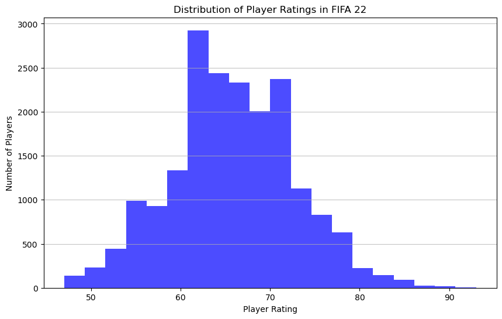

```python
# Create a histogram for player ratings
plt.figure(figsize=(10, 6))
plt.hist(fifa22_df['overall'], bins=20, color='blue', alpha=0.7)
plt.title('Distribution of Player Ratings in FIFA 22')
plt.xlabel('Player Rating')
plt.ylabel('Number of Players')
plt.grid(axis='y', alpha=0.75)
plt.show()
```

### Interesting Fact

```python
average_rating = fifa22_df['overall'].mean()
print(f"The average player rating is: {int(average_rating)}")
```

```
The average player rating is: 65
```

### Distribution of Key Predictor Variables

Exploring individual predictor variables to understand their ranges, distributions, and potential need for transformation.

#### Physical Attributes:

- `age`, `height_cm`, `weight_kg`

#### Technical Attributes:

- `pace`, `shooting`, `passing`, `dribbling`, `defending`

The following visualization highlights attribute ranges and potential transformations for better modeling.

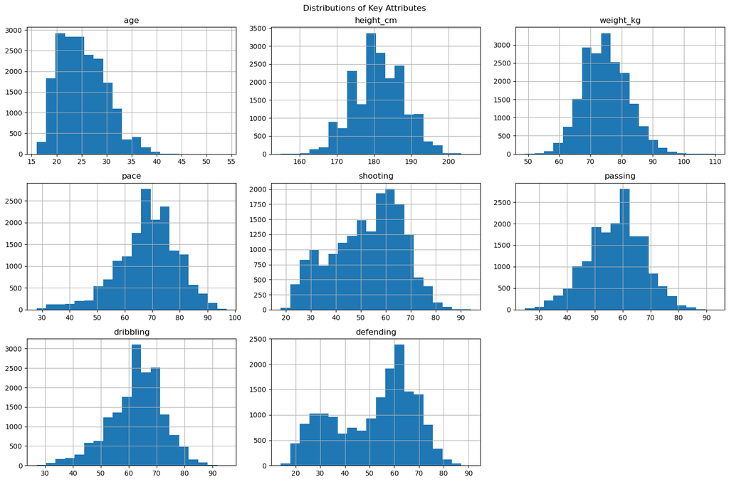

```python
# Plotting histograms for physical and technical attributes
attributes = ['age', 'height_cm', 'weight_kg', 'pace', 'shooting', 'passing', 'dribbling', 'defending']
fifa22_df[attributes].hist(bins=20, figsize=(15, 10))
plt.suptitle('Distributions of Key Attributes')
plt.tight_layout()
plt.show()
```

This next one displays the average player rating based on primary position. This is to explore positional differences in player ratings. Some positions consistently show higher ratings, which might reflect their importance in gameplay.

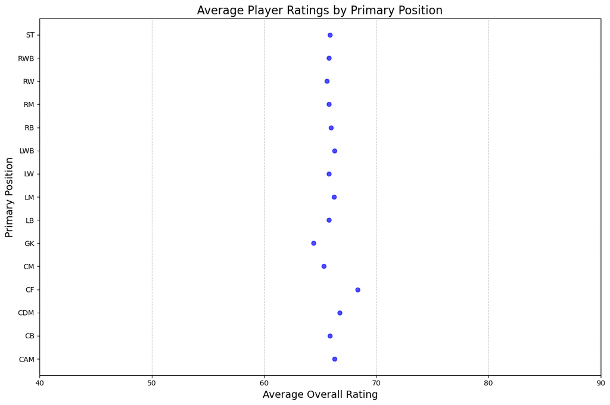

```python
average_rating_by_position = (
    fifa22_df
    .groupby(fifa22_df['player_positions'].str.split(',').str[0])['overall']
    .mean()
    .reset_index()
)

# Scatter plot of average rating by position
plt.figure(figsize=(12, 8))
plt.scatter(average_rating_by_position['overall'], average_rating_by_position['player_positions'],
            color='blue', alpha=0.7)
plt.title('Average Player Ratings by Primary Position', fontsize=16)
plt.xlabel('Average Overall Rating', fontsize=14)
plt.ylabel('Primary Position', fontsize=14)
plt.grid(axis='x', linestyle='--', alpha=0.7)
plt.xlim(40, 90)
plt.tight_layout()
plt.show()
```

## Tidying the Data

### Cleaning Process

Now that we have explored the initial dataset, we are going to remove a lot of potential outliers and unecessary data. First we shall remove all columns that are not of major use to this analysis. These are listed below. They include most elements that are unrelated to attributes as well as any integers that deal with ranking or ratings.

```python
fifa22_df = fifa22_df.drop(
    columns=[
        'sofifa_id', 'player_url', 'short_name', 'long_name', 'player_face_url', 'club_logo_url', 'club_flag_url', 'nation_logo_url',
        'nation_flag_url', 'club_team_id', 'club_name', 'league_name', 'club_jersey_number', 'club_loaned_from', 'club_joined',
        'club_contract_valid_until', 'nationality_id', 'nationality_name', 'nation_team_id', 'nation_jersey_number', 'preferred_foot',
        'weak_foot', 'skill_moves', 'international_reputation', 'work_rate', 'body_type', 'real_face', 'release_clause_eur',
        'player_tags', 'player_traits', 'dob', 'potential', 'nation_position', 'club_position', 'goalkeeping_diving',
        'goalkeeping_handling', 'goalkeeping_kicking', 'goalkeeping_positioning', 'goalkeeping_reflexes', 'goalkeeping_speed',
        'ls', 'st', 'rs', 'lw', 'lf', 'cf', 'rf', 'rw', 'lam', 'cam', 'ram', 'lm', 'lcm', 'cm', 'rcm', 'rm', 'lwb', 'ldm', 'cdm',
        'rdm', 'rwb', 'lb', 'lcb', 'cb', 'rcb', 'rb', 'gk'
    ]
)
```

```python
fifa22_df
```

|  | player_positions | overall | value_eur | wage_eur | age | height_cm | weight_kg | league_level | pace | shooting | ... | power_long_shots | mentality_aggression | mentality_interceptions | mentality_positioning | mentality_vision | mentality_penalties | mentality_composure | defending_marking_awareness | defending_standing_tackle | defending_sliding_tackle |
| --- | --- | --- | --- | --- | --- | --- | --- | --- | --- | --- | --- | --- | --- | --- | --- | --- | --- | --- | --- | --- | --- |
| 0 | RW, ST, CF | 93 | 78000000.0 | 320000.0 | 34 | 170 | 72 | 1.0 | 85.0 | 92.0 | ... | 94 | 44 | 40 | 93 | 95 | 75 | 96 | 20 | 35 | 24 |
| 1 | ST | 92 | 119500000.0 | 270000.0 | 32 | 185 | 81 | 1.0 | 78.0 | 92.0 | ... | 87 | 81 | 49 | 95 | 81 | 90 | 88 | 35 | 42 | 19 |
| 2 | ST, LW | 91 | 45000000.0 | 270000.0 | 36 | 187 | 83 | 1.0 | 87.0 | 94.0 | ... | 93 | 63 | 29 | 95 | 76 | 88 | 95 | 24 | 32 | 24 |
| 3 | LW, CAM | 91 | 129000000.0 | 270000.0 | 29 | 175 | 68 | 1.0 | 91.0 | 83.0 | ... | 81 | 63 | 37 | 86 | 90 | 93 | 93 | 35 | 32 | 29 |
| 4 | CM, CAM | 91 | 125500000.0 | 350000.0 | 30 | 181 | 70 | 1.0 | 76.0 | 86.0 | ... | 91 | 76 | 66 | 88 | 94 | 83 | 89 | 68 | 65 | 53 |
| ... | ... | ... | ... | ... | ... | ... | ... | ... | ... | ... | ... | ... | ... | ... | ... | ... | ... | ... | ... | ... | ... |
| 19234 | CDM | 47 | 70000.0 | 1000.0 | 22 | 180 | 64 | 1.0 | 58.0 | 35.0 | ... | 30 | 52 | 42 | 38 | 43 | 42 | 37 | 38 | 43 | 48 |
| 19235 | CM | 47 | 110000.0 | 500.0 | 19 | 175 | 70 | 1.0 | 59.0 | 39.0 | ... | 38 | 49 | 39 | 51 | 49 | 44 | 47 | 37 | 44 | 47 |
| 19236 | CM | 47 | 100000.0 | 500.0 | 21 | 178 | 72 | 1.0 | 60.0 | 37.0 | ... | 34 | 51 | 38 | 45 | 46 | 39 | 36 | 38 | 44 | 48 |
| 19237 | ST | 47 | 110000.0 | 500.0 | 19 | 173 | 66 | 1.0 | 68.0 | 46.0 | ... | 41 | 34 | 14 | 47 | 40 | 49 | 47 | 10 | 14 | 11 |
| 19238 | CAM | 47 | 110000.0 | 500.0 | 19 | 167 | 61 | 1.0 | 68.0 | 38.0 | ... | 36 | 55 | 42 | 47 | 46 | 35 | 36 | 33 | 31 | 37 |

19239 rows × 43 columns

### Looking Better, But More Reduction Needed

Now that we have reduced our columns from 110 to 43, we can reduce the complexity of the rows. There are a few issues with the rows at the moment. One noticeable issue is the use of multiple positions for specific players. While these players are diverse and can definitely play several positions, to reduce redundancy and potential overheightened data, we shall assign each player to a primary position only. We are also going to remove any players whose primary position is GK. Goalkeepers are incredibly important in the game; however, these players are rated based on different attributes than the other positional players. So, for the same reason we removed GK attributes from the columns, we will remove GKs from the rows. All of this should reduce the complexity of the data we are working with.

```python
fifa22_df['player_positions'] = fifa22_df['player_positions'].str.split(',').str[0]
fifa22_df = fifa22_df[fifa22_df['player_positions'] != 'GK']
```

```python
fifa22_df
```

|  | player_positions | overall | value_eur | wage_eur | age | height_cm | weight_kg | league_level | pace | shooting | ... | power_long_shots | mentality_aggression | mentality_interceptions | mentality_positioning | mentality_vision | mentality_penalties | mentality_composure | defending_marking_awareness | defending_standing_tackle | defending_sliding_tackle |
| --- | --- | --- | --- | --- | --- | --- | --- | --- | --- | --- | --- | --- | --- | --- | --- | --- | --- | --- | --- | --- | --- |
| 0 | RW | 93 | 78000000.0 | 320000.0 | 34 | 170 | 72 | 1.0 | 85.0 | 92.0 | ... | 94 | 44 | 40 | 93 | 95 | 75 | 96 | 20 | 35 | 24 |
| 1 | ST | 92 | 119500000.0 | 270000.0 | 32 | 185 | 81 | 1.0 | 78.0 | 92.0 | ... | 87 | 81 | 49 | 95 | 81 | 90 | 88 | 35 | 42 | 19 |
| 2 | ST | 91 | 45000000.0 | 270000.0 | 36 | 187 | 83 | 1.0 | 87.0 | 94.0 | ... | 93 | 63 | 29 | 95 | 76 | 88 | 95 | 24 | 32 | 24 |
| 3 | LW | 91 | 129000000.0 | 270000.0 | 29 | 175 | 68 | 1.0 | 91.0 | 83.0 | ... | 81 | 63 | 37 | 86 | 90 | 93 | 93 | 35 | 32 | 29 |
| 4 | CM | 91 | 125500000.0 | 350000.0 | 30 | 181 | 70 | 1.0 | 76.0 | 86.0 | ... | 91 | 76 | 66 | 88 | 94 | 83 | 89 | 68 | 65 | 53 |
| ... | ... | ... | ... | ... | ... | ... | ... | ... | ... | ... | ... | ... | ... | ... | ... | ... | ... | ... | ... | ... | ... |
| 19234 | CDM | 47 | 70000.0 | 1000.0 | 22 | 180 | 64 | 1.0 | 58.0 | 35.0 | ... | 30 | 52 | 42 | 38 | 43 | 42 | 37 | 38 | 43 | 48 |
| 19235 | CM | 47 | 110000.0 | 500.0 | 19 | 175 | 70 | 1.0 | 59.0 | 39.0 | ... | 38 | 49 | 39 | 51 | 49 | 44 | 47 | 37 | 44 | 47 |
| 19236 | CM | 47 | 100000.0 | 500.0 | 21 | 178 | 72 | 1.0 | 60.0 | 37.0 | ... | 34 | 51 | 38 | 45 | 46 | 39 | 36 | 38 | 44 | 48 |
| 19237 | ST | 47 | 110000.0 | 500.0 | 19 | 173 | 66 | 1.0 | 68.0 | 46.0 | ... | 41 | 34 | 14 | 47 | 40 | 49 | 47 | 10 | 14 | 11 |
| 19238 | CAM | 47 | 110000.0 | 500.0 | 19 | 167 | 61 | 1.0 | 68.0 | 38.0 | ... | 36 | 55 | 42 | 47 | 46 | 35 | 36 | 33 | 31 | 37 |

17107 rows × 43 columns

## EDA of FIFA Dataset

```python
# Display summary statistics
summary_stats = fifa22_df.describe()
summary_stats
```

|  | overall | value_eur | wage_eur | age | height_cm | weight_kg | league_level | pace | shooting | passing | ... | power_long_shots | mentality_aggression | mentality_interceptions | mentality_positioning | mentality_vision | mentality_penalties | mentality_composure | defending_marking_awareness | defending_standing_tackle | defending_sliding_tackle |
| --- | --- | --- | --- | --- | --- | --- | --- | --- | --- | --- | --- | --- | --- | --- | --- | --- | --- | --- | --- | --- | --- |
| count | 17107.000000 | 1.704100e+04 | 17054.000000 | 17107.000000 | 17107.000000 | 17107.000000 | 17054.000000 | 17107.000000 | 17107.000000 | 17107.000000 | ... | 17107.000000 | 17107.000000 | 17107.000000 | 17107.000000 | 17107.000000 | 17107.000000 | 17107.000000 | 17107.000000 | 17107.000000 | 17107.000000 |
| mean | 65.940726 | 2.965082e+06 | 9350.281459 | 25.087683 | 180.398141 | 74.101245 | 1.356515 | 68.213071 | 52.345297 | 57.312562 | ... | 51.035015 | 59.273514 | 50.500438 | 55.346233 | 55.847782 | 51.506752 | 60.049278 | 50.716666 | 52.322324 | 49.929912 |
| std | 6.771037 | 7.717024e+06 | 19874.070926 | 4.628755 | 6.544951 | 6.698788 | 0.750159 | 10.933155 | 14.051623 | 10.068965 | ... | 15.722801 | 13.851654 | 18.439604 | 14.270299 | 12.601153 | 12.406456 | 10.266863 | 17.369196 | 18.457431 | 18.362541 |
| min | 47.000000 | 1.500000e+04 | 500.000000 | 16.000000 | 155.000000 | 49.000000 | 1.000000 | 28.000000 | 18.000000 | 25.000000 | ... | 11.000000 | 20.000000 | 10.000000 | 12.000000 | 13.000000 | 13.000000 | 30.000000 | 10.000000 | 10.000000 | 10.000000 |
| 25% | 62.000000 | 5.250000e+05 | 1000.000000 | 21.000000 | 176.000000 | 70.000000 | 1.000000 | 62.000000 | 42.000000 | 51.000000 | ... | 39.000000 | 50.000000 | 35.000000 | 48.000000 | 48.000000 | 42.000000 | 53.000000 | 37.000000 | 37.000000 | 34.000000 |
| 50% | 66.000000 | 1.000000e+06 | 3000.000000 | 25.000000 | 180.000000 | 74.000000 | 1.000000 | 69.000000 | 54.000000 | 58.000000 | ... | 54.000000 | 60.000000 | 56.000000 | 58.000000 | 57.000000 | 51.000000 | 60.000000 | 55.000000 | 59.000000 | 56.000000 |
| 75% | 70.000000 | 2.100000e+06 | 9000.000000 | 29.000000 | 185.000000 | 78.000000 | 1.000000 | 76.000000 | 63.000000 | 64.000000 | ... | 63.000000 | 70.000000 | 65.000000 | 65.000000 | 65.000000 | 61.000000 | 67.000000 | 64.000000 | 66.000000 | 64.000000 |
| max | 93.000000 | 1.940000e+08 | 350000.000000 | 54.000000 | 203.000000 | 110.000000 | 5.000000 | 97.000000 | 94.000000 | 93.000000 | ... | 94.000000 | 95.000000 | 91.000000 | 96.000000 | 95.000000 | 93.000000 | 96.000000 | 93.000000 | 93.000000 | 92.000000 |

8 rows × 42 columns

The histogram used in the previous section was super resourceful, showing the spread of player ratings. It revealed that most players fall with a certain range of ratings (60-70), making for a rough looking bell-curve. Few players are on the extreme high or low ends.

Next we can compare these ratings by position to attempt to get some more useful information from the rating category. This can be done with a dot plot as seen below. It illustrates the average player rating based on their primary position. There are some outliers from the norm. These may prove key to look into.

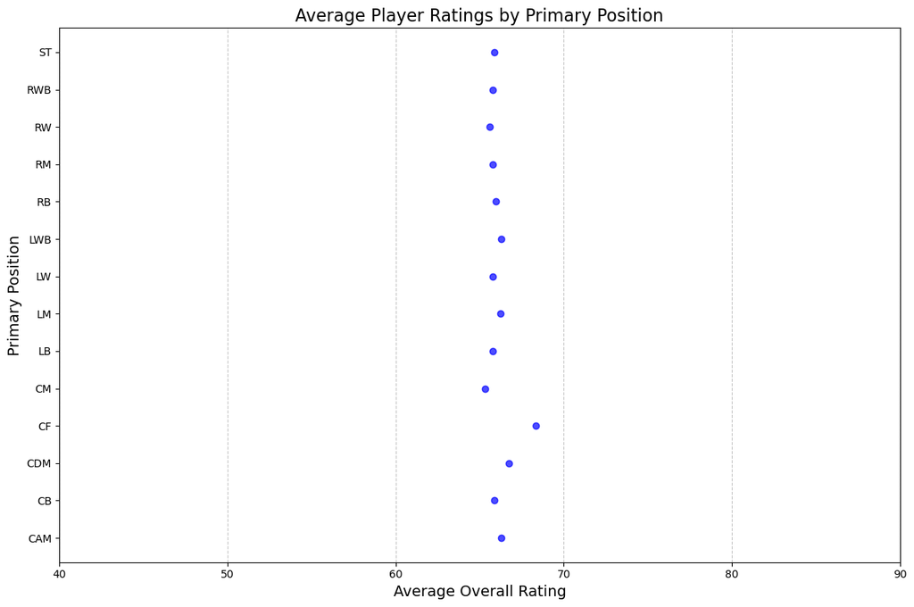

```python
average_rating_by_position = fifa22_df.groupby(fifa22_df['player_positions'])['overall'].mean().reset_index()

# Create the scatter plot
plt.figure(figsize=(12, 8))
plt.scatter(average_rating_by_position['overall'], average_rating_by_position['player_positions'], color='blue', alpha=0.7)

plt.title('Average Player Ratings by Primary Position', fontsize=16)
plt.xlabel('Average Overall Rating', fontsize=14)
plt.ylabel('Primary Position', fontsize=14)
plt.grid(axis='x', linestyle='--', alpha=0.7)

plt.xlim(40, 90)  # Adjust limits based on rating range
plt.tight_layout()
plt.show()
```

Now we are going to look into some comparisons of potential attributes and how each relates to the overall rating of a player. For simplicity, we shall start with Dribbling, Pace, Shooting, Passing, and Defending. A key goal would be to have some sort of overlay of all attributes so as to compare them looking at outliers and suspiciously high rated players with no attributes to support it.

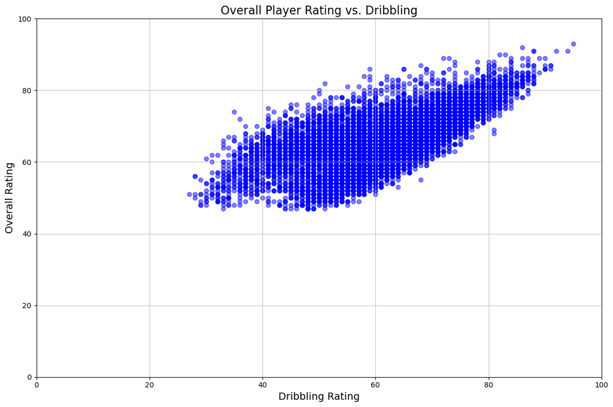

```python
# Create the scatter plot
plt.figure(figsize=(12, 8))
plt.scatter(fifa22_df['dribbling'], fifa22_df['overall'], alpha=0.5, color='blue')

plt.title('Overall Player Rating vs. Dribbling', fontsize=16)
plt.xlabel('Dribbling Rating', fontsize=14)
plt.ylabel('Overall Rating', fontsize=14)
plt.grid(alpha=0.7)

plt.xlim(0, 100)  # Adjust limits based on rating range
plt.ylim(0, 100)
plt.tight_layout()
plt.show()
```

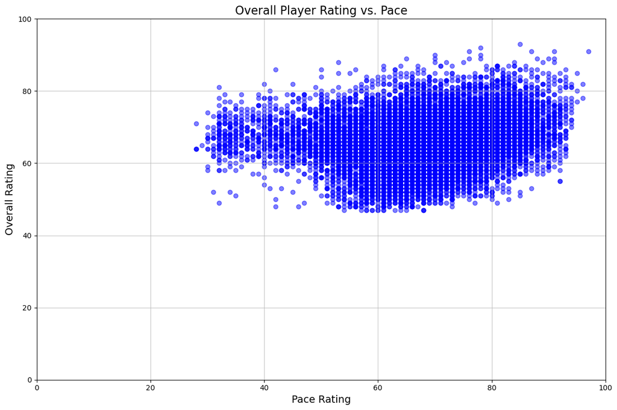

```python
# Create the scatter plot
plt.figure(figsize=(12, 8))
plt.scatter(fifa22_df['pace'], fifa22_df['overall'], alpha=0.5, color='blue')

plt.title('Overall Player Rating vs. Pace', fontsize=16)
plt.xlabel('Pace Rating', fontsize=14)
plt.ylabel('Overall Rating', fontsize=14)
plt.grid(alpha=0.7)

plt.xlim(0, 100)  # Adjust limits based on rating range
plt.ylim(0, 100)
plt.tight_layout()
plt.show()
```

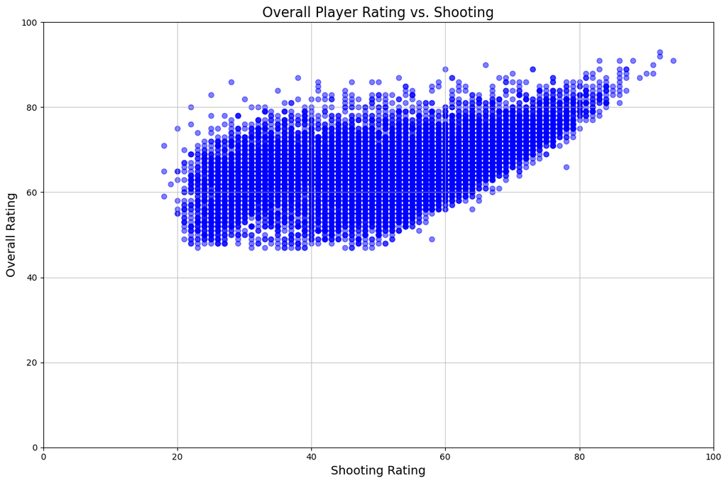

```python
# Create the scatter plot
plt.figure(figsize=(12, 8))
plt.scatter(fifa22_df['shooting'], fifa22_df['overall'], alpha=0.5, color='blue')

plt.title('Overall Player Rating vs. Shooting', fontsize=16)
plt.xlabel('Shooting Rating', fontsize=14)
plt.ylabel('Overall Rating', fontsize=14)
plt.grid(alpha=0.7)

plt.xlim(0, 100)  # Adjust limits based on rating range
plt.ylim(0, 100)
plt.tight_layout()
plt.show()
```

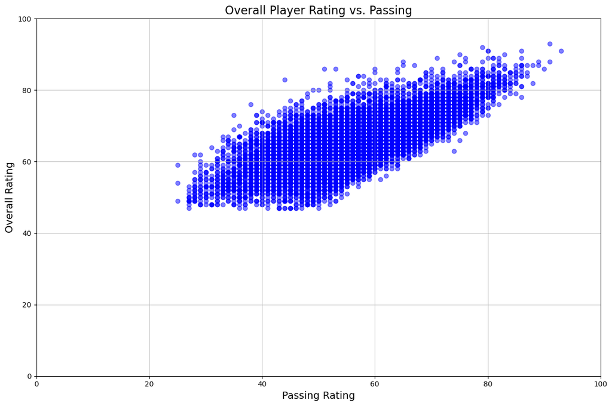

```python
# Create the scatter plot
plt.figure(figsize=(12, 8))
plt.scatter(fifa22_df['passing'], fifa22_df['overall'], alpha=0.5, color='blue')

plt.title('Overall Player Rating vs. Passing', fontsize=16)
plt.xlabel('Passing Rating', fontsize=14)
plt.ylabel('Overall Rating', fontsize=14)
plt.grid(alpha=0.7)

plt.xlim(0, 100)  # Adjust limits based on rating range
plt.ylim(0, 100)
plt.tight_layout()
plt.show()
```

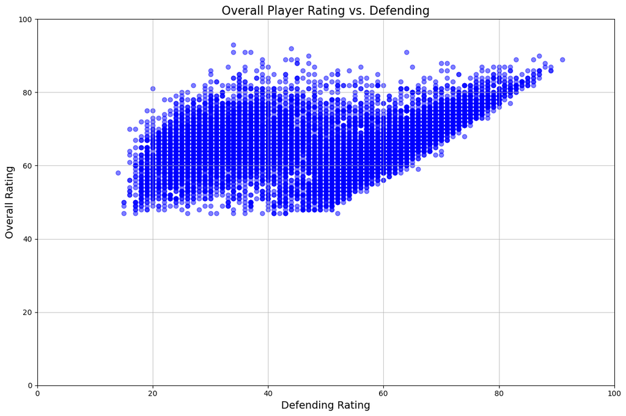

```python
# Create the scatter plot
plt.figure(figsize=(12, 8))
plt.scatter(fifa22_df['defending'], fifa22_df['overall'], alpha=0.5, color='blue')

plt.title('Overall Player Rating vs. Defending', fontsize=16)
plt.xlabel('Defending Rating', fontsize=14)
plt.ylabel('Overall Rating', fontsize=14)
plt.grid(alpha=0.7)

plt.xlim(0, 100)  # Adjust limits based on rating range
plt.ylim(0, 100)
plt.tight_layout()
plt.show()
```

The following histogram shows the age range which may be a contributing factor in FIFA. As players get older, they tend to decline after a peak age of approximately 29. Seeing if this is true according to the dataset will be interesting.

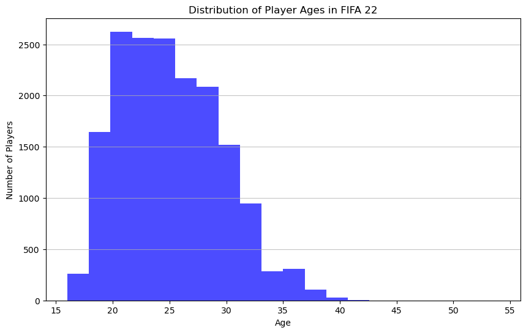

```python
plt.figure(figsize=(10, 6))
plt.hist(fifa22_df['age'], bins=20, color='blue', alpha=0.7)
plt.title('Distribution of Player Ages in FIFA 22')
plt.xlabel('Age')
plt.ylabel('Number of Players')
plt.grid(axis='y', alpha=0.75)
plt.show()
```

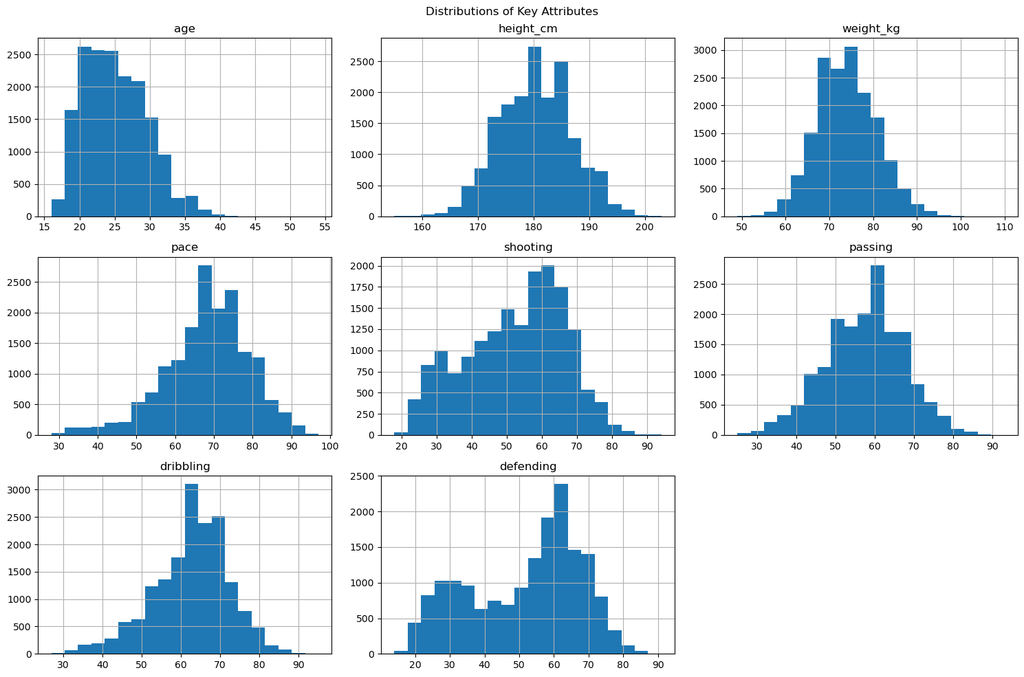

```python
# Plotting histograms for physical and technical attributes
attributes = ['age', 'height_cm', 'weight_kg', 'pace', 'shooting', 'passing', 'dribbling', 'defending']
fifa22_df[attributes].hist(bins=20, figsize=(15, 10))
plt.suptitle('Distributions of Key Attributes')
plt.tight_layout()
plt.show()
```

### Correlation Analysis

This heatmap explores relationships between the attributes to attempt to identify strong correlations with the target variable and between predictors.

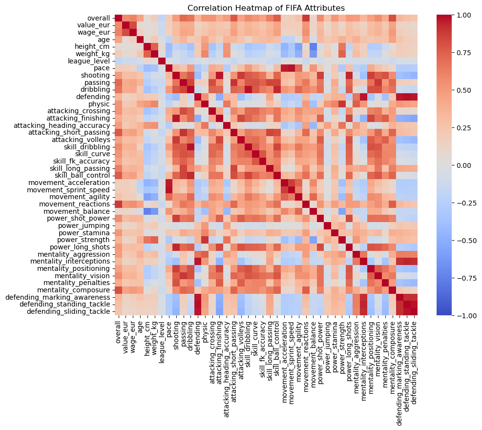

```python
# Select only numeric columns
numeric_columns = fifa22_df.select_dtypes(include=['number'])

# Display correlation heatmap for numeric columns
plt.figure(figsize=(10, 8))
sns.heatmap(
    numeric_columns.corr(),
    fmt=".2f",
    cmap="coolwarm",
    vmin=-1,
    vmax=1
)
plt.title("Correlation Heatmap of FIFA Attributes")
plt.show()
```

### Positional Analysis

Comparing average `overall` ratings by player position to identify positional trends and potential biases in player ratings.

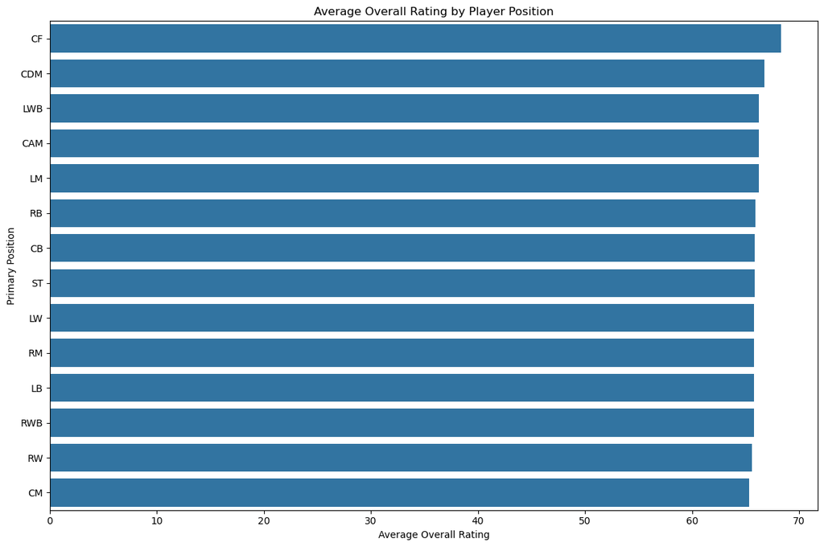

```python
# Average player ratings by position
average_rating_by_position = (
    fifa22_df
    .groupby('player_positions')['overall']
    .mean()
    .sort_values(ascending=False)
    .reset_index()
)

plt.figure(figsize=(12, 8))
sns.barplot(
    y='player_positions',
    x='overall',
    data=average_rating_by_position
)
plt.title("Average Overall Rating by Player Position")
plt.xlabel("Average Overall Rating")
plt.ylabel("Primary Position")
plt.tight_layout()
plt.show()
```

### Preparing for Modeling

Based on the EDA, the following steps will guide the modeling process:

- **Target Variable**: `overall`
- **Predictor Variables**: `pace`, `shooting`, `passing`, `dribbling`, `defending`, `age`, `height_cm`, and others.
- **Next Steps**:
  1. Scale or transform variables with non-linear relationships (e.g., `age`).
  2. Perform feature selection based on correlation and variance.
  3. Build a regression model to predict `overall`.

```python
# Feature selection based on correlation analysis and domain knowledge
selected_features = ['pace', 'shooting', 'passing', 'dribbling', 'defending', 'age']

# Splitting the dataset into training and testing sets
X = fifa22_df[selected_features]
y = fifa22_df['overall']

X_train, X_test, y_train, y_test = train_test_split(
    X, y, test_size=0.2, random_state=42
)

# Building the model
model = LinearRegression()

# Training the model
model.fit(X_train, y_train)

# Predictions and evaluation
y_pred = model.predict(X_test)

# Evaluate the model
mae = mean_absolute_error(y_test, y_pred)
rmse = mean_squared_error(y_test, y_pred, squared=False)
r2 = r2_score(y_test, y_pred)

print(f"MAE: {mae:.2f}, RMSE: {rmse:.2f}, R²: {r2:.2f}")
```

```
MAE: 2.97, RMSE: 3.70, R²: 0.70
```

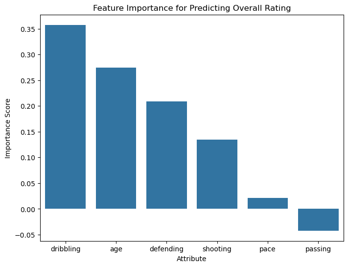

```python
feature_importance = pd.DataFrame({
    'Attribute': X_train.columns,
    'Importance': model.coef_
}).sort_values(by='Importance', ascending=False)

# Bar plot
plt.figure(figsize=(8, 6))
sns.barplot(
    data=feature_importance,
    x='Attribute',
    y='Importance'
)
plt.title("Feature Importance for Predicting Overall Rating")
plt.ylabel("Importance Score")
plt.xlabel("Attribute")
plt.show()
```

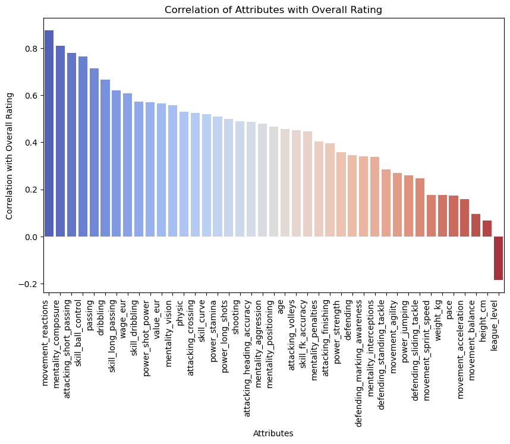

```python
# Filter out only the numeric columns
numeric_columns = fifa22_df.select_dtypes(include=['number'])

# Calculate correlation of each attribute with overall rating
correlation_with_rating = numeric_columns.corr()['overall'].drop('overall')

# Sort the correlations in descending order
correlation_sorted = correlation_with_rating.sort_values(ascending=False)

# Plot the bar chart
plt.figure(figsize=(10, 6))
sns.barplot(x=correlation_sorted.index, y=correlation_sorted.values, palette='coolwarm')
plt.title('Correlation of Attributes with Overall Rating')
plt.xlabel('Attributes')
plt.ylabel('Correlation with Overall Rating')
plt.xticks(rotation=90, ha='right')
plt.show()
```

# Conclusion

In this tutorial, we explored the FIFA 22 Complete Player dataset to uncover insights into player performance and the factors influencing overall player ratings. This dataset provided a wealth of information, including player ratings, attributes, and positions, making it an excellent resource for comprehensive analysis. Its structure allowed for easy exploration, enabling the extraction of meaningful insights aligned with our tutorial's objectives. My personal interest in sports (soccer) and gaming motivated this project, as it made analyzing the data both enjoyable and rewarding. The tutorial aimed to determine the key characteristics that define successful players and how these attributes may vary across different playing positions.

To achieve these goals, we developed a regression model that leverages player attributes—such as pace, defending, passing, and age—to predict overall player ratings. The model's performance was evaluated using key metrics:

- Mean Absolute Error (MAE): 2.97
- Root Mean Square Error (RMSE): 3.70
- R² (coefficient of determination): 0.70

These results indicate that the model provides a reasonably accurate prediction of player ratings based on available attributes. While there is room for improvement, the findings are sufficient to identify which attributes most significantly impact player performance. This aligns with the original goal of determining the factors that contribute to successful performance in the dataset.

By combining data analysis with predictive modeling, this tutorial delivers insights that resonate with a broad audience, including gamers, coaches, and sports enthusiasts. The findings underline the intersection of data science and sports/e-sports, offering practical applications and an enhanced understanding of player dynamics.

## Takeaways

From the exploration and modeling of the FIFA 22 dataset, several important takeaways can be found. Here’s a summary:

### Data Analysis & Modeling Takeaways:

Complexity vs. Simplicity: While sophisticated modeling techniques can be applied, much of the dataset's value can be extracted using simpler methods, highlighting the importance of starting with foundational approaches before scaling complexity.

### Possible Future Work

Positional Analysis: Expand analysis to explore specific roles (e.g., center-back vs. full-back attributes) to reveal role-specific trends

Age: Determine how much age plays a role in position rating and if it shows trends for attributes as well

Rating Prediction: Use the dataset to attempt to predict on unknown data, players, or games. Using real game data would be another metric to attempt to predict rating score. Real statistics and metrics can be analyzed for how relevant they are to the game rating

These takeaways underline the rich potential of the FIFA 22 dataset for analyzing trends, predicting player value, and even aiding strategic decision-making in football management.